# Exam 2

## Exam 2

#### Question

1. Suponha que um sinal $x(t)$ será amostrado e quantizado através de um quantizador escalar uniforme. O sinal $x(t)$ possui extensão $[0, 1]$. Um quantizador qualquer pode ser expresso por uma função $Q: \mathbb{R} \rightarrow \{y_1, \ldots, y_M\}$, onde $M$ representa o número de níveis de quantização e $y_i$, $i=1,\ldots,M$, os pontos de representação. Considerando um quantizador uniforme com 2 bits, faça o que se pede:
   1. Determine os pontos de representação $y_i$ e os limiares do quantizador, $t_i$;
      - opção a-A = $y=$`[0.125, 0.375, 0.625, 0.875]` e $t=$`[0.25, 0.5, 0.75]`
      - opção a-B = $y=$`[-0.5, 0, 0.5]` e $t=$`[-0.25, 0, 0.25]`
      - opção a-C = $y=$`[0, 0.25, 0.5, 0.75]` e $t=$`[0.125, 0.375, 0.625]`
      - opção a-D = $y=$`[0.25, 0.5, 0.75, 1]` e $t=$`[0.375, 0.625, 0.875]`
   2. Usualmente, para avaliar a performance de um quantizador, utiliza-se o erro médio quadrático (MSE), e para tanto, utilizamos como medida de distorção o quadrado da diferença, $d(x,Q(x)) = (x - Q(x))^2$. Calcule o valor esperado da distorção $D(Q)$ para um sinal de entrada com distribuição uniforme.
   3. Calcule a relação sinal-ruído de quantização para um sinal de entrada com distribuição uniforme.
   4. Calcule a relação sinal-ruído de quantização para um sinal de entrada senoidal $x(t) = \frac{1}{2}\left( 1 + \sin(\omega t) \right)$.
   1. opção a-A / opção a-B / opção a-C / opção a-D / nenhuma das anteriores
   2. $D(Q) =$
   3. $D(Q) =$
   4. $\text{SQNR} =$

#### Solution

   Como o quantizador é de 2-bits, teremos $2^2 = 4$ pontos de representação no intervalo $[0,1]$. Iremos dividir o intervalo $[0,1]$ em 4 regiões de mesmo tamanho ($0.25$): $[0,0.25)$, $[0.25,0.5)$, $[0.5,0.75)$, $[0.75,1]$. Os limiares então serão: 0.25, 0.5 e 0.75. Os pontos de representação serão colocados no meio de cada intervalo: 0.125, 0.375, 0.625 e 0.875.

   Abaixo seguem os cálculos de $D(Q)$ para um sinal com distribuição uniforme na entrada. Para facilitar, reconhecemos que cada uma das 4 integrais no somatório possuem o mesmo valor.
   $$\begin{aligned}
   D(Q) &= \sum_i \int_{t_{i-1}}^{t_i} f(x) (x - y_i)^2 \mathrm{d}x \\
   &= \frac{1}{4} \left( \int_{0}^{0.25}(x-0.125)^2 dx + \int_{0.25}^{0.5}(x-0.375)^2 dx + \int_{0.5}^{0.75}(x-0.625)^2 dx + \int_{0.75}^{1}(x-0.875)^2 dx \right) \\
   &= \frac{1}{4} \times 4 \times \left( \int_{0}^{0.25}(x-0.125)^2 dx \\
   &= \left(\left(\frac{1}{8}\right)^2 x - \frac{1}{4} x^2 + \frac{x^3}{3} \right) \Bigg\rvert_0^{\frac{1}{4}} \\
   &= \frac{1}{192} .
   \end{aligned}$$

   A relação sinal-ruído de quantização pode ser obtida utilizando a expressão:
   $$\text{SQNR} = 10 \log \left( \frac{\sigma_x^2}{\sigma_q^2} \right)$$
   onde, para o quantizador uniforme temos
   $$\sigma_q^2 = \frac{\Delta^2}{12}$$
   e para o sinal de entrada $x \sim \mathcal{U}(a,b)$ temos
   $$\sigma_x^2 = \frac{(b-a)^2}{12}$$
   e assim para $x \sim \mathcal{U}(0,1)$ teremos $\sigma_x^2 = \frac{1}{12}$. A relação sinal-ruído de quantização, para o quantizador com $n=2$ bits e $\Delta = 1/2^n$ = 1/4, será então
   $$\text{SQNR} = 10 \log \left( \frac{\frac{1}{12}}{\frac{1/16}{12}} \right) = 10 \log 16 = 12.0412 \text{dB}.$$

   Para calcular a SQNR para o sinal senoidal proposto, note que $x(t) = \frac{1}{2} + A \sin(\omega t)$, onde $A = \frac{1}{2}$. A constante não muda o resultado e poderemos utilizar a fórmula:
   $$\text{SQRN} = 6n + 1.76 \text{dB} ,$$
   onde $n$ é o número de bits do quantizador. Teremos então um $\text{SQNR} = 13.76 \text{dB}$. Se calcularmos utilizando $\Delta = \frac{1}{4}$ e $\sigma_x^2 = \frac{1}{8}$, obteremos o mesmo resultado:
   $$\text{SQNR} = 10 \log \left( \frac{\sigma_x^2}{\sigma_q^2} \right) = 10 \log \left( \frac{12 \sigma_x^2}{\Delta^2} \right) = 10 \log 24 \text{dB}.$$
   1. True. / False. / False. / False. / False
   2. $D(Q) = \frac{1}{192} = 0.0052083$.
   3. $\text{SQNR} = 10 \log 16 = 12.0412$dB.
   4. $\text{SQNR} = 10 \log 24 = 13.80211$dB.

#### Question

2. Considere o exemplo visto em aula (notebook) em que tomaremos a cada dois pixels de uma imagem e consideraremos cada par como um vetor em $\mathbb{R}^2$. Cada par de pixel $x = (x_1, x_2)$ será representado por um ponto no plano $x_1 \times x_2$ onde $x_1$ é o eixo das abscissas e $x_2$ o eixo das ordenadas. Os números associados a cada região representam o índice da saída do quantizador associado a cada uma delas. Os pontos em preto representam pares de pixels da foto da Lena.

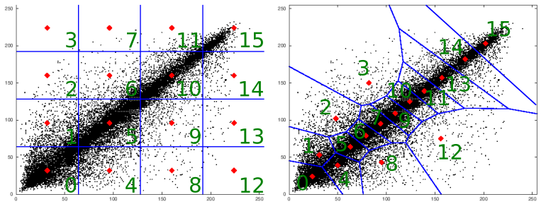

   Podemos afirmar que:
   1. Ambos quantizadores vetoriais utilizam o mesmo número de bits.
   2. O quantizador uniforme possui menor distorção.
   3. A sequência de pixels `[100, 25, 225, 230]` terá como saída do quantizador uniforme os índices `[4,15]`.
   4. A sequência de pixels `[100, 25, 225, 230]` terá como saída do quantizador não-uniforme os índices `[8,15]`.
   5. Podemos afirmar que o quantizador não-uniforme, obtido pelo algoritmo de Lloyds, e apresentado na figura, é o quantizador ótimo (com menor distorção).

#### Solution

   1. True.
   2. False.
   3. True.
   4. True.
   5. False.

#### Question

3. A figura abaixo ilustra o processo de quantização de cores de uma imagem. À esquerda temos a imagem original, no meio uma palheta de cores e à direita a imagem resultante da quantização de cores.

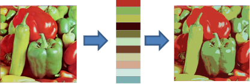

   Com relação a este processo de quantização, podemos afirmar que:
   1. É possível reduzir o número de bits necessários para representar uma imagem utilizando uma quantização de cores.
   2. A quantização de cores é uma quantização escalar.
   3. A palheta de cores é única, ou seja, só existe uma forma de se obter/criar uma palheta de cores.
   4. O dithering pode ser utilizado conjuntamente com a quantização para obtermos uma imagem com menos regiões de cores chapadas, criando a sensação de uma imagem mais realista.
   5. A palheta de cores deve ter menos do que 256 cores para ser possível obter uma taxa de compressão maior do que 1 (um).
   6. A palheta de cores deve ter mais do que 256 cores para criar uma representação natural de imagens reais (fotos).
   7. O algoritmo de corte de mediana é utilizado para criar uma palheta de cores com tamanho $2^n$.
   8. A melhor forma (menor distorção e maior taxa de compressão) de se obter uma palheta de cores é dividir uniformemente o espaço de cores, atribuindo o mesmo número de bits para as componentes R, G e B.
   9. O dithering pode ser utilizado na quantização cores conjuntamente com qualquer método para obter a palheta de cores.

#### Solution

   1. True.
   2. False.
   3. False.
   4. True.
   5. False.
   6. False.
   7. True.
   8. False.
   9. True.

#### Question

4. Considere o sistema de reamostragem apresentado na Figura abaixo.

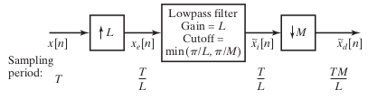

   Seja $x[n]$ o sinal de entrada, com transformada de Fourier dada por $X(e^{j\omega})$ apresentado na Figura a seguir:

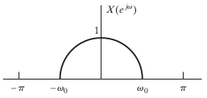

   Para cada uma dos valores de $L$ e $M$, especifique (em radianos) qual é o maior valor possível para $\omega_0$ de forma que $\tilde{X}_d(e^{j\omega}) = aX(e^{j M \omega /L})$ para alguma constante $a$.
   1. $M=3$ e $L=2$
   2. $M=5$ e $L=2$
   3. $M=2$ e $L=3$